# Stats Thèse Max

Thomas HUSSON

2025-10-21

# Import de la base de données

```r
gs4_deauth()
df <- read_sheet(
  "https://docs.google.com/spreadsheets/d/1eWwPK8G89G6nWTDzWimcCa8EOWqval8RPvwykZmfGoI/edit?gid=803820517#gid=803820517",
  sheet = "CopieThomas"
)
```

# Statistiques descriptives

## Recodages des variables pour lisibilité

```r
#Factor l'Âge dans le bon ordre :
df <- df %>%
  mutate(`3_Age` = factor(`3_Age`,
                          levels = c("Entre 30 et 39 ans",
                                     "Entre 40 et 49 ans",
                                     "Entre 50 et 59 ans",
                                     "Entre 60 et 69 ans",
                                     "Plus de 70 ans")))


#Factor la durée d'installation dans le bon ordre
df <- df %>%
  mutate(`6_Duree_d_installation` = factor(`6_Duree_d_installation`,
                                           levels = c("Moins de 5 ans",
                                                      "Entre 5 et 9 ans",
                                                      "Entre 10 et 19 ans",
                                                      "Plus de 20 ans")))



#Factor les types d'activité dans le bon ordre
df <- df %>%
  mutate(`7_Type_d_activite` = factor(`7_Type_d_activite`,
                                      levels = c("Exclusivement libéral en cabinet",
                                                 "Essentiellement libéral avec activité universitaire",
                                                 "Essentiellement libéral avec activité de régulation/PDSA",
                                                 "Mixte (libéral + hospitalière)",
                                                 "Autre")))
```

## Description de chaques médecins : par graphiques

### Connaissance MCS

- Variable : df$`1_Connaissance_MCS_binaire`

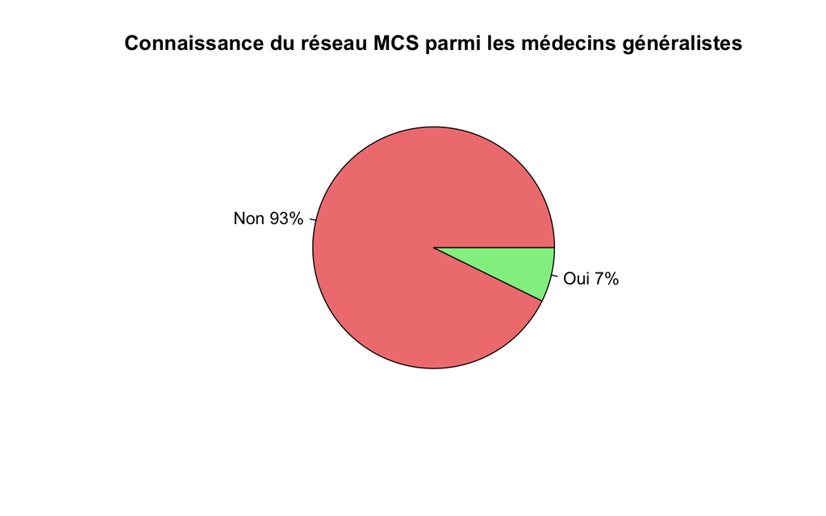

### Sexe

[figure not shown]

### Âge

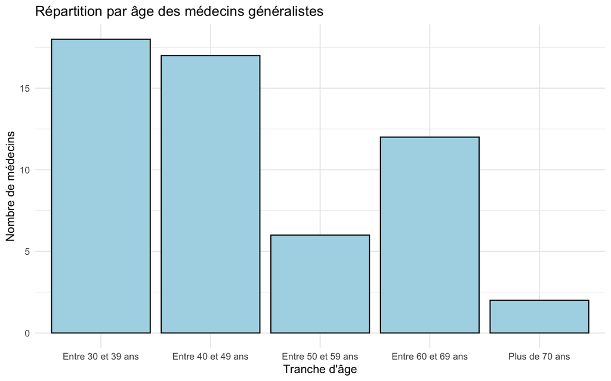

### Lieu d’installation : carte des répondants

[interactive chart not shown]

### Durée d’installation :

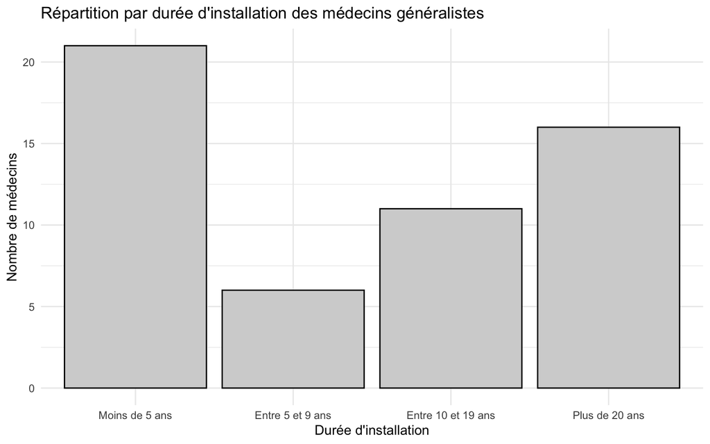

### Type d’activité :

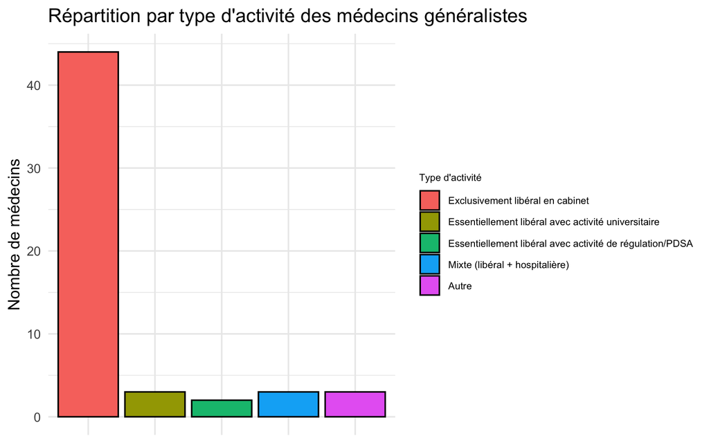

Représentation en camembert :

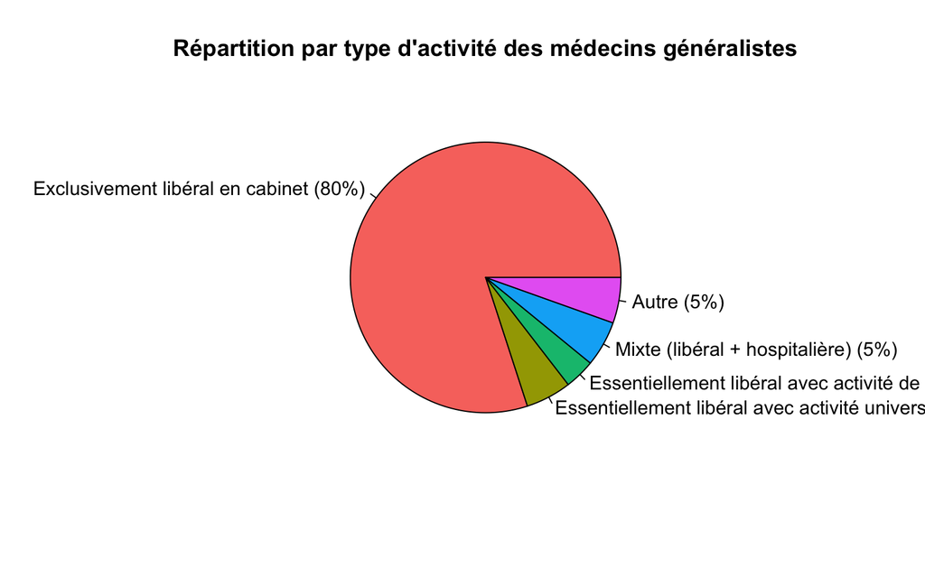

### Types de visites

- Variables incluses : 8__consultations_rdv 8__consultations_sans_rdv_ 8_consultations_:*creneaux_d_urgence 8_Visites 8_Cs_autre 8bis_En_cas_de_reponse*”Autre”*merci_de_preciser*[Commentaire]

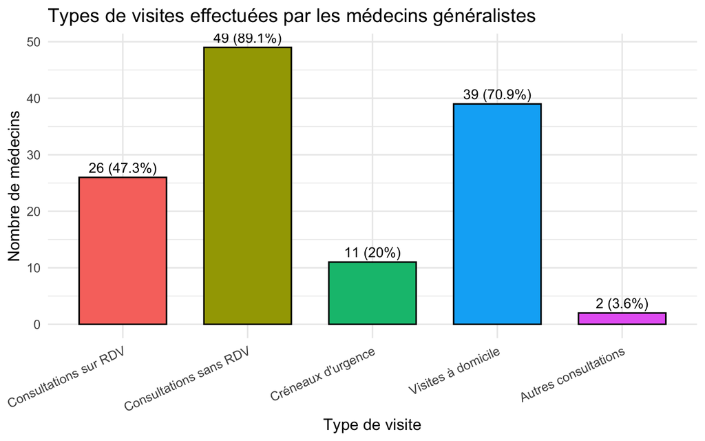

### Ressenti sur le délai d’intervention du SMUR :

- Variable : df$`9_Ressenti_delai_SMUR`

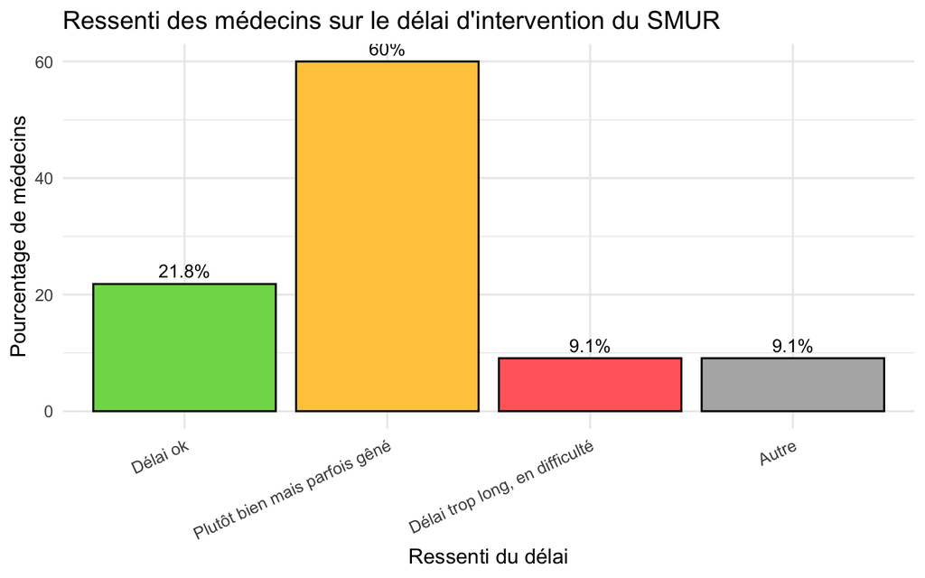

- **AUTRES** : représentés par :
  - “*Pas ou peu d’urgences vraies. Pour la semi urgence, on a toujours réussi à se dépatouiller : amélioration de l’état clinique par les médicaments sur place ou récupérés à la pharma en urgence par la famille ou alors transport hospitalier ””rapide”” 0 médicalisé par la famille. Par contre en cas d’urgence réelle, je pressens que l’équation pourrait être problématique.*”
  - “*Il y a un cabinet qui gère les urgences à 50 mètres du mien*”
  - “*Délai de prise en charge fortement modulé selon l’utilisation de l’hélicoptère ou 0, intérêt+++ de la télé médecine au sein du CH de Cilaos*”
  - “*les délais sont longs mais la perception dépend de l’urgence*”

#### Idem mais camembert avec mêmes couleurs

- Variable : df$`9_Ressenti_delai_SMUR`

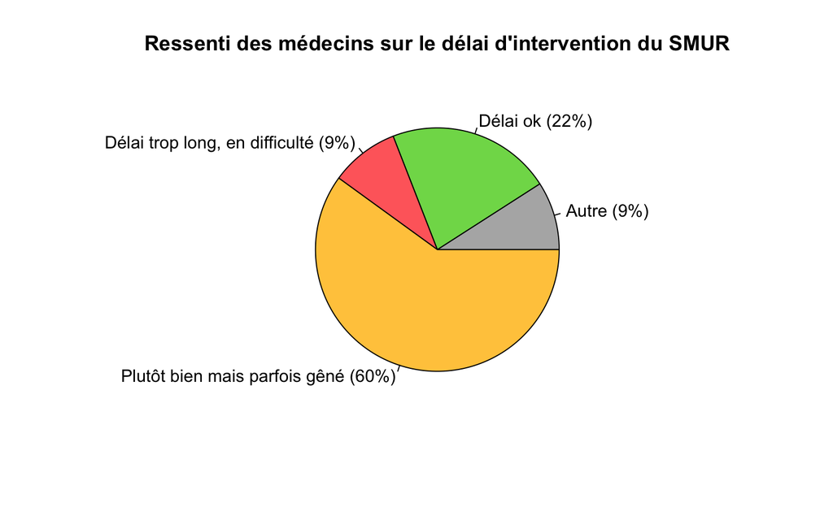

#### Carte

[interactive chart not shown]

### Perte de chance dans le secteur liée au délai d’intervention du SMUR

#### Histogramme

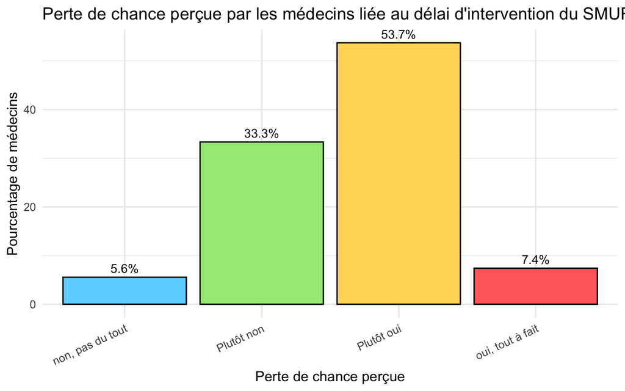

#### Camembert

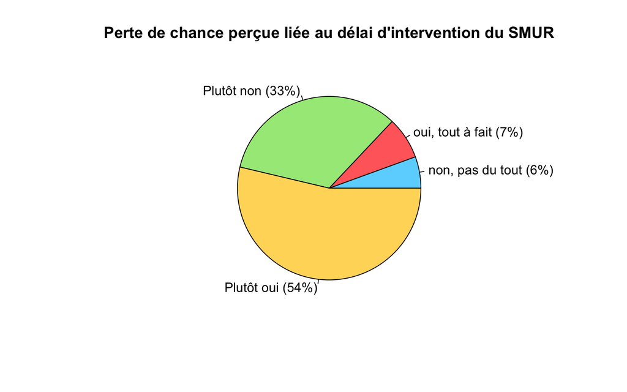

#### Carte

[interactive chart not shown]

#### Tableau récapitulatif

2 colonnes incluses :

- `9_Ressenti_delai_SMUR``
- `10_Delai_d_intervention_:_perte_de_chance_dans_votre_secteur``

```r
cols_to_include2 <- c(
  "9_Ressenti_delai_SMUR",
  "10_Delai_d_intervention_:_perte_de_chance_dans_votre_secteur"
)

#Ordonner les facteurs pour lisibilité
df <- df %>%
  mutate(`9_Ressenti_delai_SMUR` = factor(`9_Ressenti_delai_SMUR`,
                                          levels = c("Délai ok",
                                                     "Plutôt bien mais parfois gêné",
                                                     "Délai trop long, en difficulté",
                                                     "Autre")))
df <- df %>%
  mutate(`10_Delai_d_intervention_:_perte_de_chance_dans_votre_secteur` = factor(`10_Delai_d_intervention_:_perte_de_chance_dans_votre_secteur`,
                                                                                   levels = c("non, pas du tout","Plutôt non","Plutôt oui","oui, tout à fait")))

table2 <- df %>%
  tbl_summary(
    include = all_of(cols_to_include2), # colonnes à inclure
    statistic = list(
      all_categorical() ~ "{n} ({p}%)" # n (%) pour les variables catégorielles
    ),
    label = list(
      `9_Ressenti_delai_SMUR` = "Ressenti sur le délai d'intervention du SMUR",
      `10_Delai_d_intervention_:_perte_de_chance_dans_votre_secteur` = "Perte de chance dans votre secteur liée au délai d'intervention"
    ),
    missing = "no" # ne pas inclure les valeurs manquantes dans le tableau
  ) %>%
  modify_header(label = "**Caractéristiques**") %>% # modifier l'en-tête de la colonne des labels
  bold_labels() # mettre en gras les labels des variables

table2
```

| **Caractéristiques** | **N = 54**<sup>1</sup> |
| --- | --- |
| Ressenti sur le délai d'intervention du SMUR |  |
| Délai ok | 12 (22%) |
| Plutôt bien mais parfois gêné | 32 (59%) |
| Délai trop long, en difficulté | 5 (9.3%) |
| Autre | 5 (9.3%) |
| Perte de chance dans votre secteur liée au délai d'intervention |  |
| non, pas du tout | 3 (5.6%) |
| Plutôt non | 18 (33%) |
| Plutôt oui | 29 (54%) |
| oui, tout à fait | 4 (7.4%) |

<sup>1</sup> n (%)

#### Perte de chance binaire liée au délai d’intervention

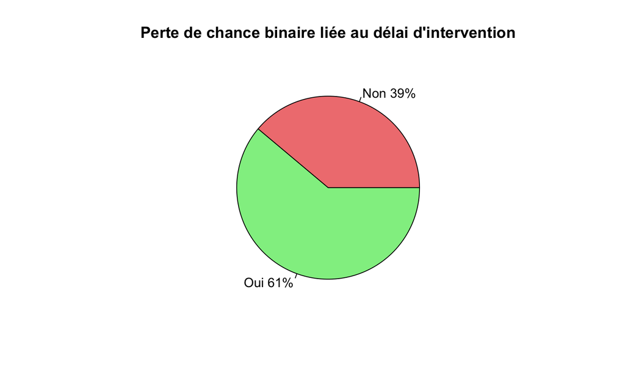

```r
slices <- table(df$`10_Delai_d_intervention_:_perte_de_chance_dans_votre_secteur_binaire`)
labels <- c("Non", "Oui")
pct <- round(slices / sum(slices) * 100)
labels <- paste(labels, pct) # Ajoute les pourcentages aux labels
labels <- paste(labels, "%", sep = "") # Ajoute le symbole %
pie(slices,
    main = "Perte de chance binaire liée au délai d'intervention",
    col = c("lightcoral", "lightgreen"),
    labels = labels
)
```

### Réseau MCS est-il pertinent pour la Réunion ?

#### Histogramme

- Variable : df$`11_Reseau_MCS_pertinent_pour_La_Reunion`

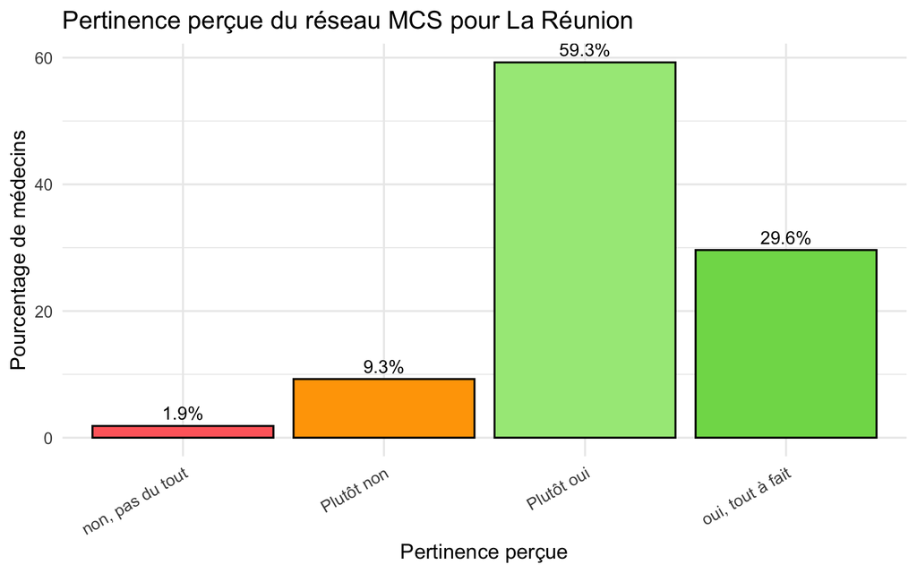

#### Camembert

- Variable : df$`11_Reseau_MCS_pertinent_pour_La_Reunion`

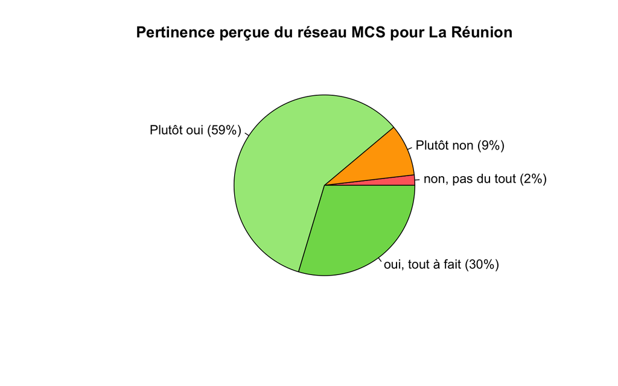

### Délai depuis dernière formation aux soins d’urgences

- Variable df$`12_Dernieres_formations_d_urgence`

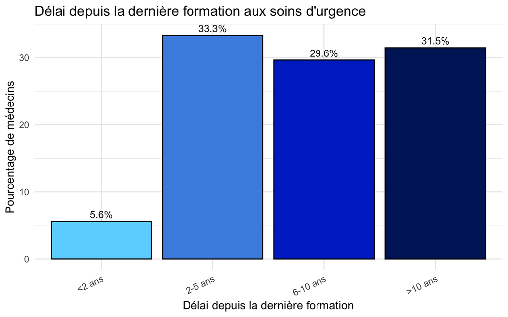

**Visualisation du rapport entre l’Âge ()df$`3_Age` et le délai depuis la dernière formation aux soins d'urgence (df$`12_Dernieres_formations_d_urgence`)**

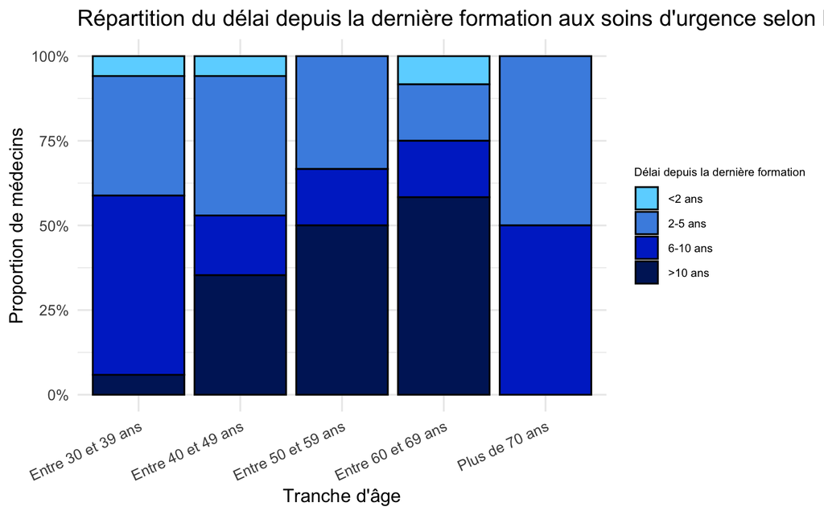

**Autres visualisations pour monsieur**

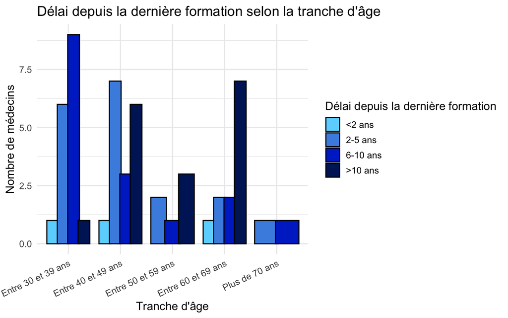

#### Cabinet adapté aux urgences

- Variable df$`13_Cabinet_adapte_aux_urgences`

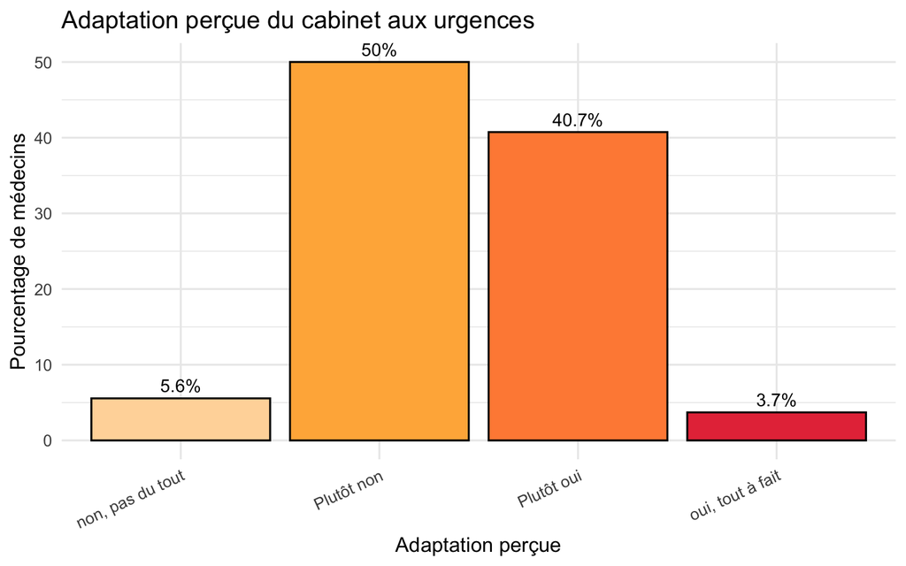

#### Intérêt pour une formation complémentaire en urgence

- Variable : df$`14_Interet_pour_formation_complementaire_en_urgence`

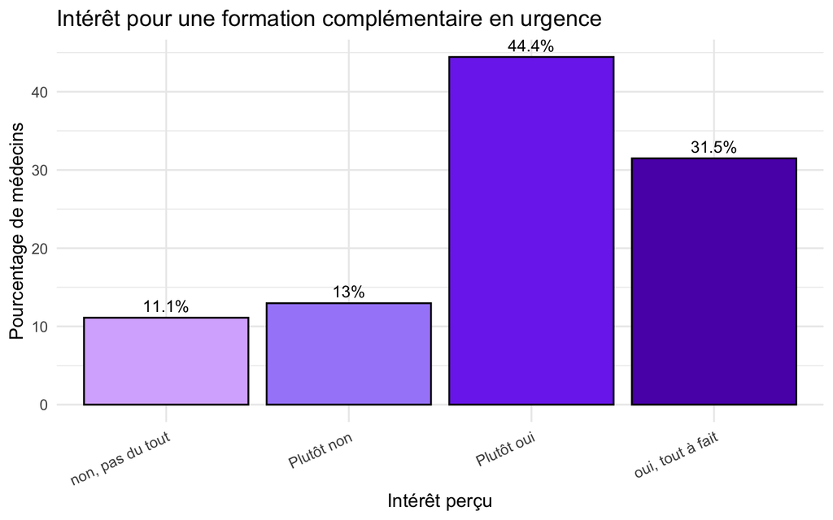

| **Caractéristiques** | **N = 54**<sup>1</sup> |
| --- | --- |
| Connaissance du réseau MCS | 4 (7.4%) |
| Sexe (Homme) | 29 (54%) |
| Âge |  |
| Entre 30 et 39 ans | 17 (31%) |
| Entre 40 et 49 ans | 17 (31%) |
| Entre 50 et 59 ans | 6 (11%) |
| Entre 60 et 69 ans | 12 (22%) |
| Plus de 70 ans | 2 (3.7%) |
| Durée d'installation (années) |  |
| Moins de 5 ans | 21 (39%) |
| Entre 5 et 9 ans | 6 (11%) |
| Entre 10 et 19 ans | 11 (20%) |
| Plus de 20 ans | 16 (30%) |
| Type d'activité |  |
| Exclusivement libéral en cabinet | 44 (81%) |
| Essentiellement libéral avec activité universitaire | 3 (5.6%) |
| Essentiellement libéral avec activité de régulation/PDSA | 2 (3.7%) |
| Mixte (libéral + hospitalière) | 2 (3.7%) |
| Autre | 3 (5.6%) |
| Consultations avec rendez-vous | 25 (46%) |
| Consultations sans rendez-vous | 48 (89%) |
| Visites | 39 (72%) |
| Autres consultations | 2 (3.7%) |

<sup>1</sup> n (%)

# Comparaison sur CJP : différences entre interessé et non interessé

- CJP : recodé en `df$CJP` codé “1”
- Utiliser le recodage binaire pour interprétation plus facile :
  - connaissance <- df$`1_Connaissance_MCS_binaire`
  - age <- df$`3_Age_inf_50a
  - sexe <- df$`2_Sexe_Homme`
  - profession_isolee <- df$`4_Profession_isolee`
  - duree_installation <- df$`6_Duree_d_installation_inf_10ans`
  - activite_autre <- df$`7_Activite_autre_que_liberal_exclusif`
  - ressenti_delai <- df$`9_Ressenti_delai_SMUR_genee_YN`
  - perte_chance <- df$`10_Delai_d_intervention_:_perte_de_chance_dans_votre_secteur_binaire`

| **Caractéristiques** | **Intéressé par MCS** N = 24<sup>1</sup> | **Non intéressé par MCS** N = 30<sup>1</sup> | **p-value**<sup>2</sup> |
| --- | --- | --- | --- |
| Connaissance du dispositif MCS | 3 (13%) | 1 (3.3%) | 0.3 |
| Âge inférieur à 50 ans | 17 (71%) | 17 (57%) | 0.3 |
| Sexe (Homme) | 15 (63%) | 14 (47%) | 0.2 |
| Durée d'installation inférieure à 10 ans | 12 (50%) | 15 (50%) | >0.9 |
| Activité autre que libéral exclusif | 6 (25%) | 4 (13%) | 0.3 |
| Consultations avec rendez-vous | 8 (33%) | 17 (57%) | 0.088 |
| Consultations sans rendez-vous | 21 (88%) | 27 (90%) | >0.9 |
| Visites | 19 (79%) | 20 (67%) | 0.3 |
| Autres consultations | 2 (8.3%) | 0 (0%) | 0.2 |
| Ressenti du délai d'intervention du SMUR gêné | 20 (83%) | 17 (57%) | 0.036 |
| Perte de chance liée au délai d'intervention (binaire) | 18 (75%) | 15 (50%) | 0.061 |
| Dernière formation aux soins d'urgence < 5 ans (binaire) | 11 (46%) | 10 (33%) | 0.3 |
| Cabinet adapté aux urgences (binaire) | 14 (58%) | 10 (33%) | 0.066 |
| Intérêt pour une formation complémentaire en urgence (binaire) | 24 (100%) | 17 (57%) | <0.001 |

<sup>1</sup> n (%)  
<sup>2</sup> Fisher’s exact test; Pearson’s Chi-squared test

Ce tableau est top mais ne permet pas vraiment de **QUANTIFIER** à quel point ces facteurs sont associés à l’intérêt pour devenir MCS.

*# Analyse univariée sur facteurs associés à l’intérêt pour devenir MCS (CJP)

- Principe de l’analyse univariée : on compare les caractéristiques des médecins selon leur intérêt (oui/non) pour devenir médecin correspondant du SAMU dans le cadre du dispositif MCS.
- Variable d’intérêt : `df$CJP` (intérêt pour devenir MCS)
- Interprétation :de l’analyse :
  - Pour chaque variable, on compare la répartition entre les médecins intéressés et non intéressés.
  - Les p-values indiquent si les différences observées sont statistiquement significatives.
  - Cela permet d’identifier les facteurs potentiellement associés à l’intérêt pour devenir MCS.
- Différence avec une multivariée :
  - L’analyse univariée examine chaque variable indépendamment, tandis que la multivariée ajuste pour plusieurs variables simultanément.
  - La multivariée permet d’identifier les facteurs indépendamment associés à l’intérêt pour devenir MCS, en tenant compte des interactions entre variables.
  - Les résultats peuvent différer entre les deux analyses en raison de la prise en compte des confounders dans la multivariée.
  - L’univariée est souvent une étape préliminaire avant la multivariée pour sélectionner les variables à inclure.
  - En résumé, l’univariée identifie des associations potentielles, tandis que la multivariée évalue les associations indépendantes.

# CJP : carte

[interactive chart not shown]